# “Análisis sobre Encuestas de Elecciones Presidenciales en Argentina (2023)”

Re Sasia Agustina, Del Giudice Rodriguez Priscilla, Martínez Lisette & Diaz Castellon Antonio

2024-10-22

# **Primer Análisis**

Comenzamos el análisis informando cuántas observaciones y variables teníamos en la encuesta.

```
##  [1] "Marca temporal"          "mail"
##  [3] "edad"                    "genero"
##  [5] "generales"               "balotaje"
##  [7] "problemas_inflacion"     "problemas_inseguridad"
##  [9] "problemas_pobreza"       "problemas_desempleo"
## [11] "problemas_corrupcion"    "problemas_desigualdad"
## [13] "problemas_educacion"     "problemas_deficit"
## [15] "orden_inflacion"         "orden_inseguridad"
## [17] "orden_pobreza"           "orden_desempleo"
## [19] "orden_corrupcion"        "orden_desigualdad"
## [21] "orden_educacion"         "orden_deficit"
## [23] "politicas_tarifas"       "politicas_boleto"
## [25] "politicas_impuestos"     "politicas_obras"
## [27] "politicas_universidades" "imagen_milei"
## [29] "imagen_grabois"          "imagen_bullrich"
## [31] "imagen_villarruel"       "imagen_llaryora"
## [33] "imagen_kicillof"         "imagen_moreno"
## [35] "imagen_deloredo"         "imagen_cfk"
## [37] "imagen_macri"            "control_precios"
## [39] "control_privatizacion"   "control_punibilidad"
```

```
## [1] 925
```

Conociendo la cantidad de observaciones y también cuáles eran las variables, decidimos indagar en las edades de las personas encuestadas.

```
##    Min. 1st Qu.  Median    Mean 3rd Qu.    Max.
##   16.00   26.00   39.00   41.21   53.00   92.00
```

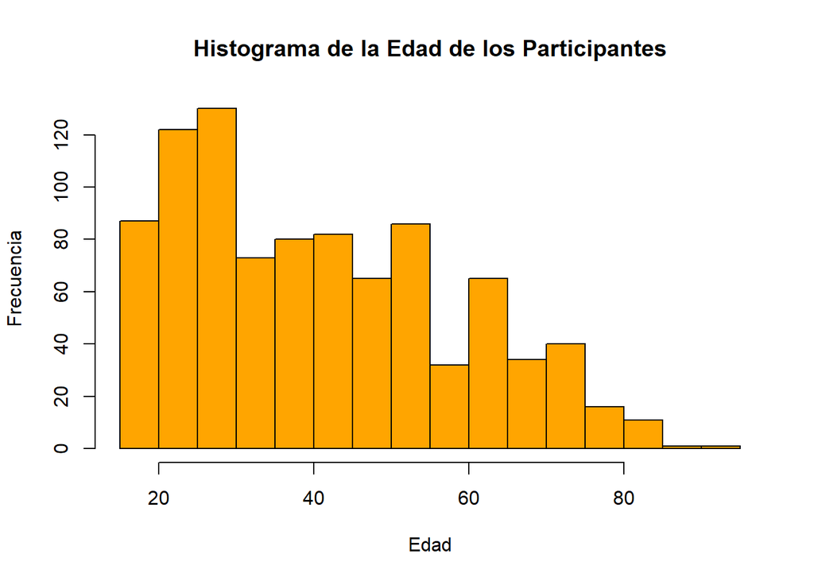

Con la distribución de edades, nos fijamos en la distribución de géneros dentro de la encuesta.Una vez finalizado este análisis inicial, nos gustaría abordar por separado el siguiente tema:

| Genero | Frecuencia |
| --- | --- |
| mujer | 452 |
| mujer trans / travesti | 4 |
| no binario | 5 |
| otra identidad / ninguna de las anteriores | 2 |
| Prefiero no contestar | 2 |
| varón | 456 |
| varón trans / masculinidad trans | 4 |

# **Voto Elegido en las Ultimas Elecciones**

| Candidato | Cantidad de Votos |
| --- | --- |
| En blanco | 29 |
| Javier Milei | 253 |
| Juan Schiaretti | 130 |
| Miriam Bregman | 52 |
| No me acuerdo | 5 |
| No voté | 87 |
| Patricia Bullrich | 155 |
| Sergio Massa | 214 |

Los resultados que aparecen en la tabla son un poco diferente con los nacionales, donde la posición del primero y del segundo están cambiadas, el resto es masomenos coherente con lo que fueron los resultados entre todas las provincias. Mientras tanto, los resultados de Córdoba también tienen la particularidad de que solo hay un intercambio entre las posiciones de dos candidatos, pero en lugar de ser entre Milei y Massa, es entre Massa y Schiaretti, donde en la encuesta el primero asciende dos puestos en comparación a la realidad, mientras que el segundo pierde esos dos puestos.

A continuación, las votaciones en el Balotaje

| Candidatos | Cantidad de Votos |
| --- | --- |
| En blanco | 79 |
| Javier Milei | 414 |
| No me acuerdo | 6 |
| No voté | 113 |
| Sergio Massa | 313 |

Los resultados muestran de ganador a Milei, la diferencia en cantidad es sin dudas más similar al resultado nacional (55,69%-44,30%) que lo que fue en Cordoba (74,05%-25,94%).Finalizada esta primera rueda de análisis más general, quisimos centrarnos en las figuras politicas más relevantes.

# **Figuras Politicas Relevantes**

Para continuar con el análisis, decidimos averiguar la imagen de varias de las figuras políticas más relevantes del país, algunos siendo candidatos a presidencia o vice, mientras que otros son figuras muy relevantes en la jerarquia de su correspondiente partido, y hay otros nombres que buscan ocupar en algún futuro un puesto más relevante en el gobierno. Para lograr esto,primero construímos todos los gráficos, para al final lograr una conclusión en base a los mismos.

## **Javier Milei**

```
##    Min. 1st Qu.  Median    Mean 3rd Qu.    Max.    NA's
##   1.000   1.000   5.000   4.691   8.000  10.000      17
```

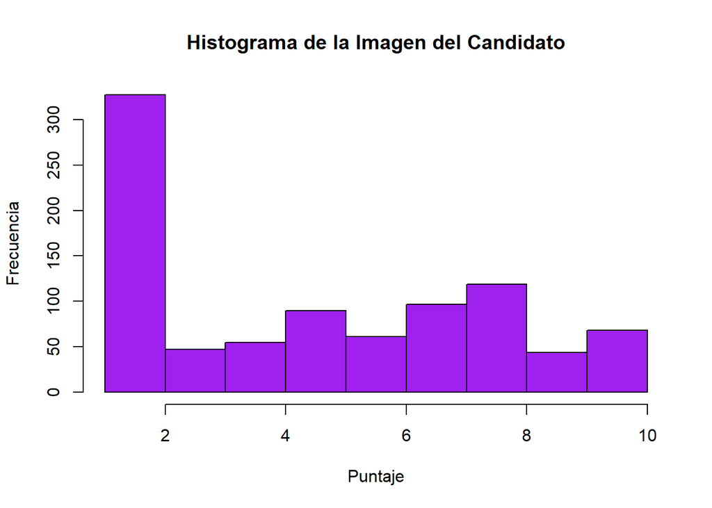

### **Género**

#### **Mujeres**

```
## [1] 4.196833
```

#### **Mujeres Trans**

```
## [1] 1
```

#### **No Binario**

```
## [1] 2.2
```

#### **Hombre**

```
## [1] 5.287305
```

#### **Hombre Trans**

```
## [1] 2.75
```

#### **Otra identidad**

```
## [1] 1
```

### **Edad**

#### **Mayores a 50**

```
## [1] 4.772242
```

#### **Menores a 30**

```
## [1] 4.738318
```

### **Juan Grabois**

```
##    Min. 1st Qu.  Median    Mean 3rd Qu.    Max.    NA's
##   1.000   1.000   3.000   3.661   6.000  10.000     165
```

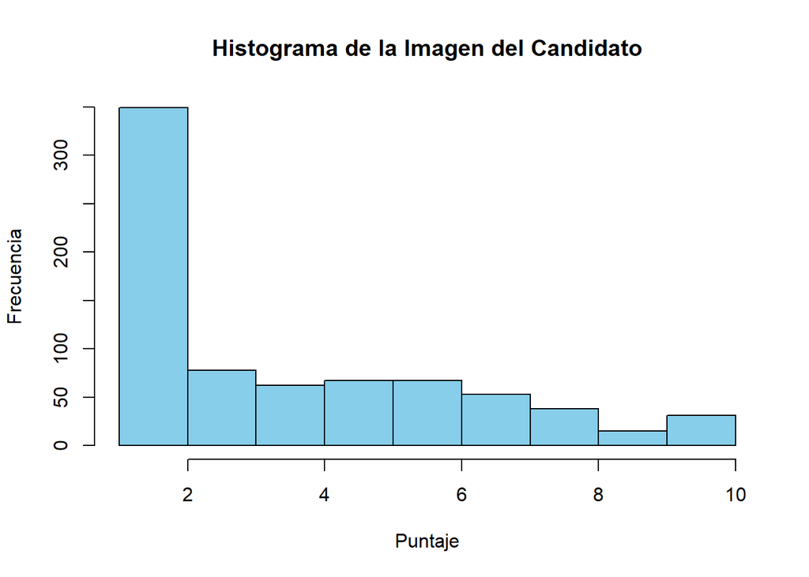

### **Género**

#### **Mujeres**

```
## [1] 3.956268
```

#### **Mujeres Trans**

```
## [1] 4.25
```

#### **No Binario**

```
## [1] 5.4
```

#### **Hombre**

```
## [1] 3.319202
```

#### **Hombre Trans**

```
## [1] 8
```

#### **Otra identidad**

```
## [1] 6.5
```

### **Edad**

#### **Mayores a 50**

```
## [1] 3.264463
```

#### **Menores a 30**

```
## [1] 3.897959
```

## **Victoria Villaruel**

```
##    Min. 1st Qu.  Median    Mean 3rd Qu.    Max.    NA's
##   1.000   1.000   5.000   4.647   7.000  10.000      50
```

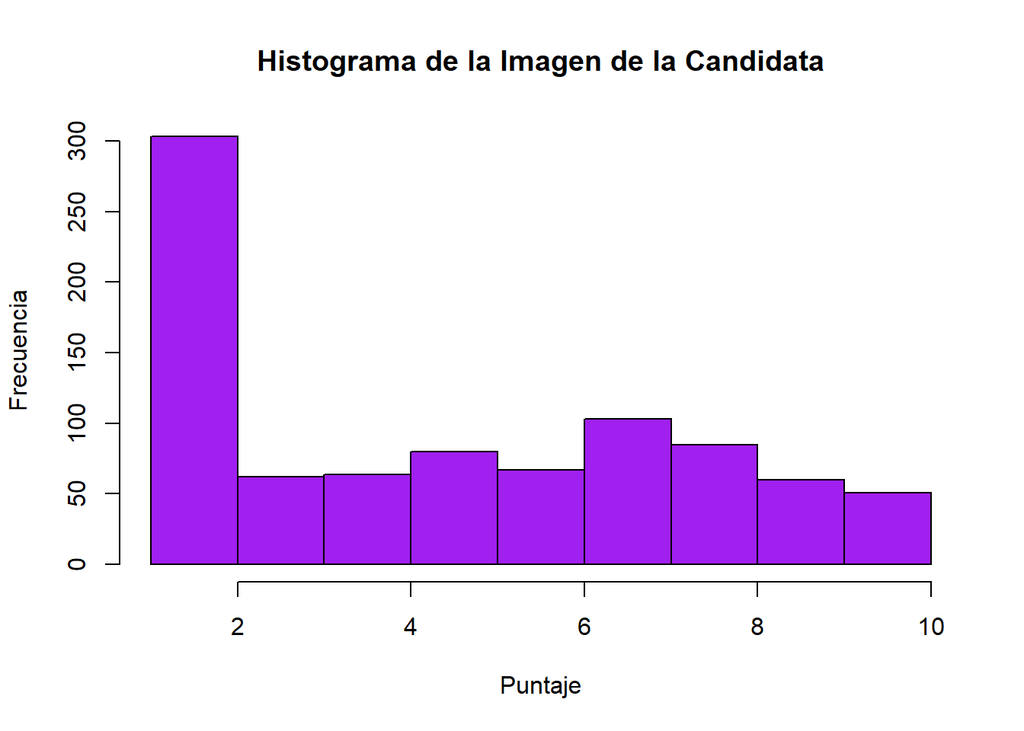

### **Género**

#### **Mujeres**

```
## [1] 4.378571
```

#### **Mujeres Trans**

```
## [1] 1.25
```

#### **No Binario**

```
## [1] 2.5
```

#### **Hombre**

```
## [1] 5.004556
```

#### **Hombre Trans**

```
## [1] 2.75
```

#### **Otra identidad**

```
## [1] 1
```

### **Edad**

#### **Mayores a 50**

```
## [1] 4.772894
```

#### **Menores a 30**

```
## [1] 4.54902
```

## **Patricia Bullrich**

```
##    Min. 1st Qu.  Median    Mean 3rd Qu.    Max.    NA's
##   1.000   1.000   4.000   4.352   7.000  10.000      22
```

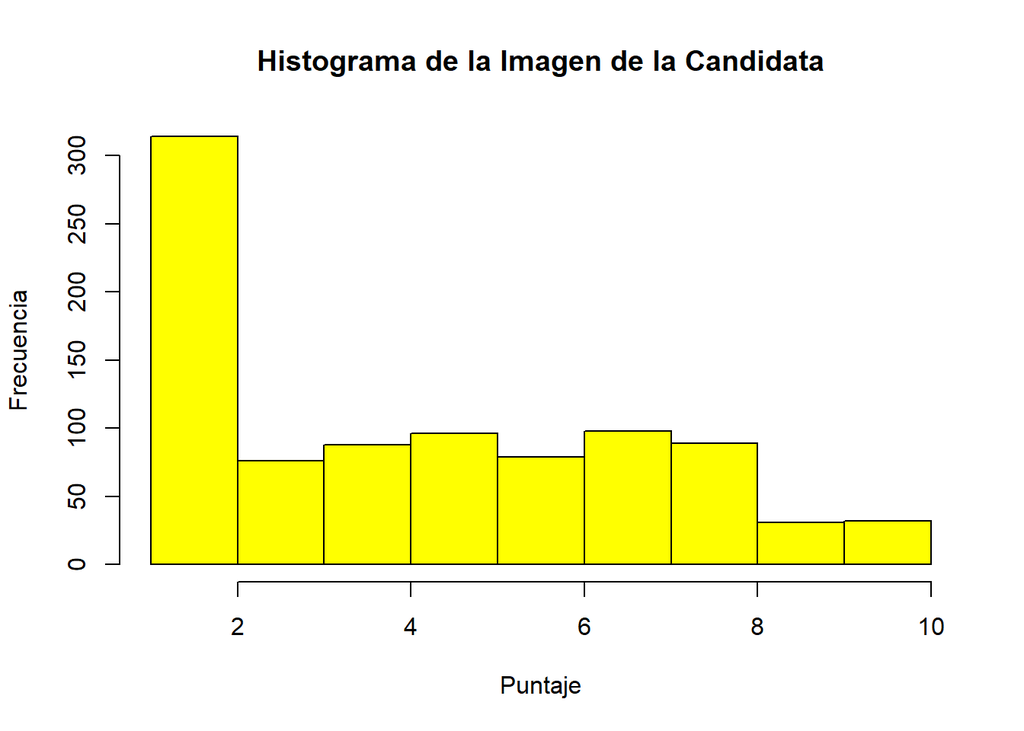

### **Género**

#### **Mujeres**

```
## [1] 4.330317
```

#### **Mujeres Trans**

```
## [1] 1
```

#### **No Binario**

```
## [1] 2.4
```

#### **Hombre**

```
## [1] 4.472973
```

#### **Hombre Trans**

```
## [1] 2.5
```

#### **Otra identidad**

```
## [1] 1
```

### **Edad**

#### **Mayores a 50**

```
## [1] 4.812057
```

#### **Menores a 30**

```
## [1] 4.095238
```

## **Martín Llaryora**

```
##    Min. 1st Qu.  Median    Mean 3rd Qu.    Max.    NA's
##   1.000   3.000   4.000   4.386   6.000  10.000      69
```

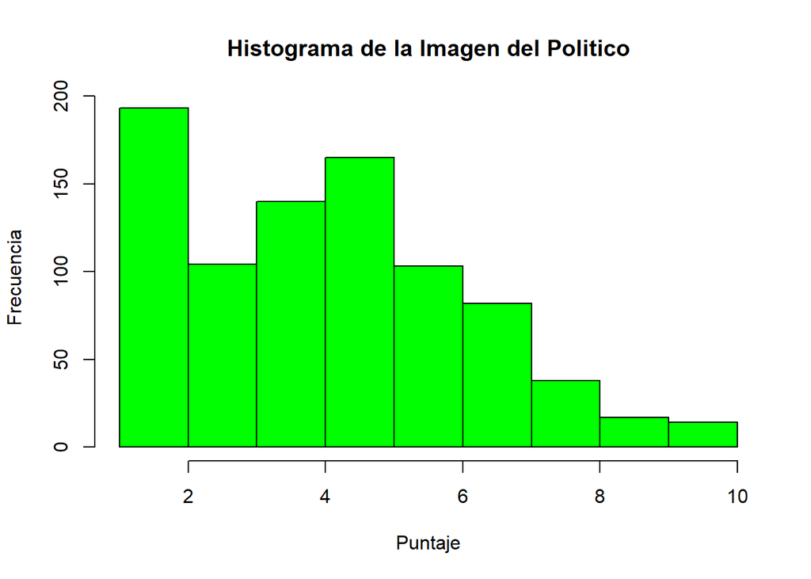

### **Género**

#### **Mujeres**

```
## [1] 4.351942
```

#### **Mujeres Trans**

```
## [1] 2.75
```

#### **No Binario**

```
## [1] 4.8
```

#### **Hombre**

```
## [1] 4.443925
```

#### **Hombre Trans**

```
## [1] 4.666667
```

#### **Otra identidad**

```
## [1] 1
```

### **Edad**

#### **Mayores a 50**

```
## [1] 4.66791
```

#### **Menores a 30**

```
## [1] 4.253472
```

## **Axel Kicillof**

```
##    Min. 1st Qu.  Median    Mean 3rd Qu.    Max.    NA's
##   1.000   1.000   3.000   3.528   6.000  10.000      61
```

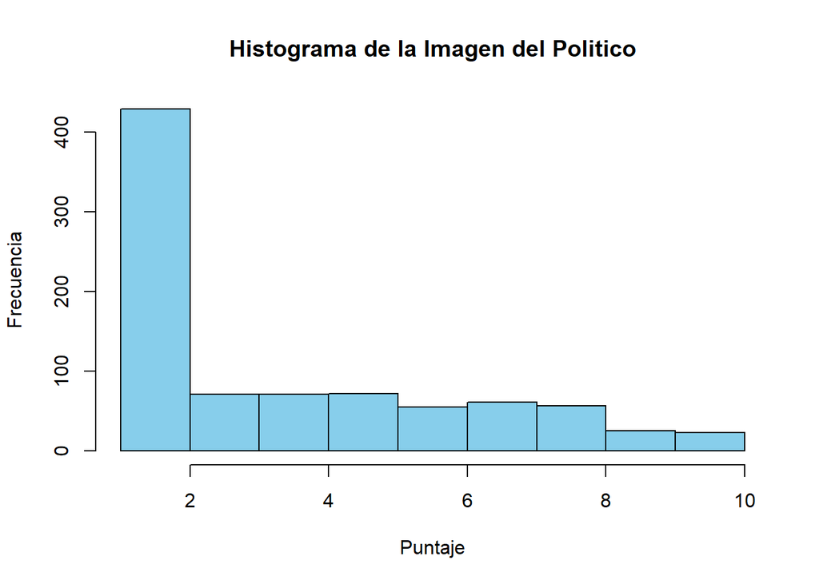

### **Género**

#### **Mujeres**

```
## [1] 3.64891
```

#### **Mujeres Trans**

```
## [1] 4.5
```

#### **No Binario**

```
## [1] 6.4
```

#### **Hombre**

```
## [1] 3.33871
```

#### **Hombre Trans**

```
## [1] 6
```

#### **Otra identidad**

```
## [1] 1.5
```

### **Edad**

#### **Mayores a 50**

```
## [1] 3.335793
```

#### **Menores a 30**

```
## [1] 3.595238
```

## **Guillermo Moreno**

```
##    Min. 1st Qu.  Median    Mean 3rd Qu.    Max.    NA's
##   1.000   1.000   2.000   3.061   5.000  10.000     204
```

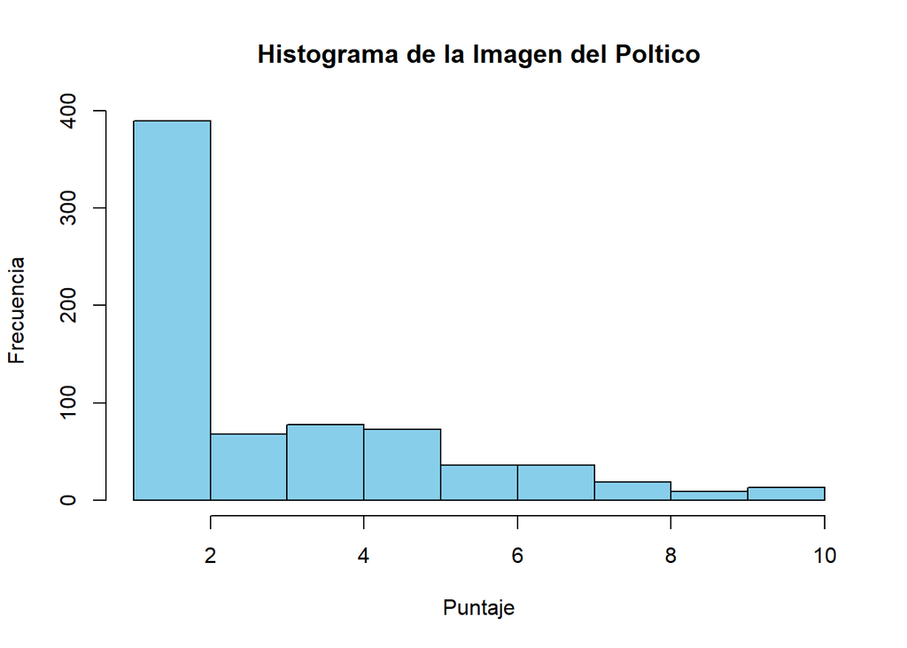

### **Género**

#### **Mujeres**

```
## [1] 2.841615
```

#### **Mujeres Trans**

```
## [1] 4
```

#### **No Binario**

```
## [1] 4.2
```

#### **Hombre**

```
## [1] 3.203655
```

#### **Hombre Trans**

```
## [1] 5.75
```

#### **Otra identidad**

```
## [1] 1.5
```

### **Edad**

#### **Mayores a 50**

```
## [1] 2.78629
```

#### **Menores a 30**

```
## [1] 3.352113
```

## **Rodrigo de Loredo**

```
##    Min. 1st Qu.  Median    Mean 3rd Qu.    Max.    NA's
##   1.000   2.000   4.000   3.801   5.000  10.000     211
```

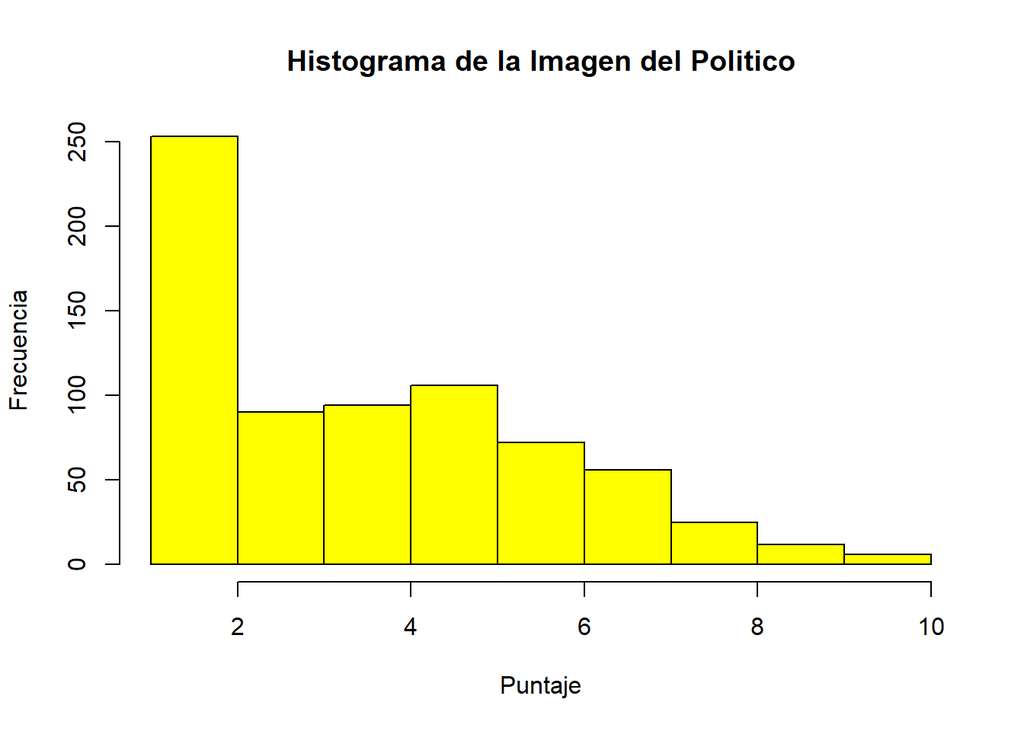

### **Género**

#### **Mujeres**

```
## [1] 3.821958
```

#### **Mujeres Trans**

```
## [1] 2
```

#### **No Binario**

```
## [1] 3
```

#### **Hombre**

```
## [1] 3.835165
```

#### **Hombre Trans**

```
## [1] 2.5
```

#### **Otra identidad**

```
## [1] 2
```

### **Edad**

#### **Mayores a 50**

```
## [1] 4.095652
```

#### **Menores a 30**

```
## [1] 3.616071
```

## **Cristina Fernandez de Kirchner**

```
##    Min. 1st Qu.  Median    Mean 3rd Qu.    Max.    NA's
##   1.000   1.000   2.000   3.485   6.000  10.000      29
```

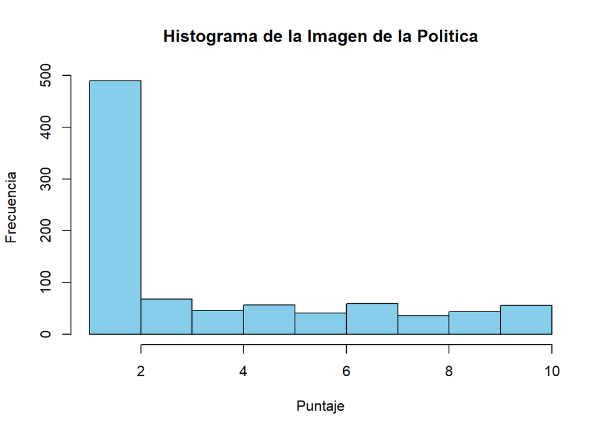

### **Género**

#### **Mujeres**

```
## [1] 3.525114
```

#### **Mujeres Trans**

```
## [1] 5
```

#### **No Binario**

```
## [1] 6.8
```

#### **Hombre**

```
## [1] 3.353741
```

#### **Hombre Trans**

```
## [1] 7
```

#### **Otra identidad**

```
## [1] 3.5
```

### **Edad**

#### **Mayores a 50**

```
## [1] 3.236559
```

#### **Menores a 30**

```
## [1] 3.503185
```

## **Mauricio Macri**

```
##    Min. 1st Qu.  Median    Mean 3rd Qu.    Max.    NA's
##   1.000   1.000   4.000   3.882   6.000  10.000      22
```

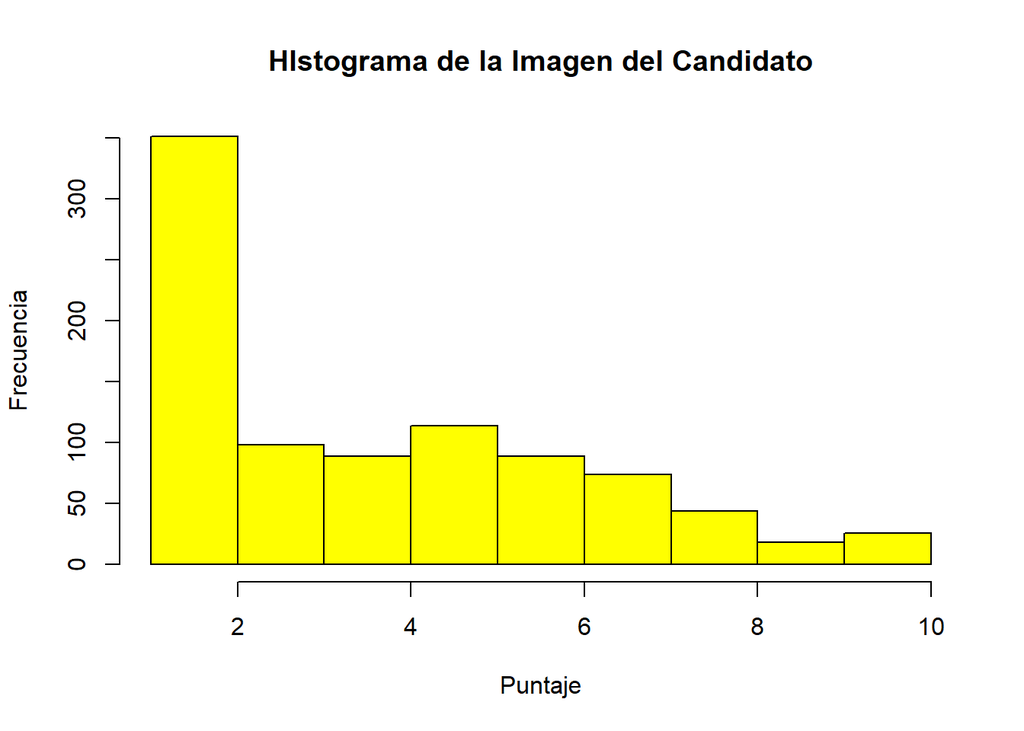

### **Género**

#### **Mujeres**

```
## [1] 3.893182
```

#### **Mujeres Trans**

```
## [1] 2
```

#### **No Binario**

```
## [1] 2.8
```

#### **Hombre**

```
## [1] 3.943946
```

#### **Hombre Trans**

```
## [1] 1.75
```

#### **Otra identidad**

```
## [1] 1
```

### **Edad**

#### **Mayores a 50**

```
## [1] 4.226148
```

#### **Menores a 30**

```
## [1] 3.792994
```

### **General (Mediante Intervalos de Confianza)**

#### Milei

```
##   Estimate   CI lower   CI upper Std. Error
##  4.6905286  4.4856372  4.8954201  0.1043989
```

#### Grabois

```
##   Estimate   CI lower   CI upper Std. Error
## 3.66052632 3.46758055 3.85347208 0.09828655
```

#### Bullrich

```
##   Estimate   CI lower   CI upper Std. Error
## 4.35215947 4.17008732 4.53423161 0.09277101
```

#### Villaruel

```
##   Estimate   CI lower   CI upper Std. Error
##  4.6468571  4.4454417  4.8482726  0.1026226
```

#### Llaryora

```
##   Estimate   CI lower   CI upper Std. Error
## 4.38551402 4.23699201 4.53403603 0.07567066
```

#### Kicillof

```
##   Estimate   CI lower   CI upper Std. Error
## 3.52777778 3.34487243 3.71068312 0.09318989
```

#### Moreno

```
##   Estimate   CI lower   CI upper Std. Error
## 3.06102635 2.88995967 3.23209304 0.08713381
```

#### De Loredo

```
##   Estimate   CI lower   CI upper Std. Error
## 3.80112045 3.63402164 3.96821925 0.08511133
```

#### Cristina

```
##   Estimate   CI lower   CI upper Std. Error
##  3.4854911  3.2847932  3.6861890  0.1022603
```

#### Macri

```
##   Estimate   CI lower   CI upper Std. Error
## 3.88150609 3.71404142 4.04897076 0.08532808
```

Lo que nos puede decir estos intervalos de confianza es que existen conexiones entre ciertos intervalos que nos permitirian hacer ciertos niveles de aceptación. Siendo os siguientes

#### **Imagen Positiva**

En este primer nivel podemos poner a 1° Milei 2° Villaruel 3° Llaryora 4° Bullrich

#### **Imagen Negativa**

Y Finalizamos con Moreno, el cual no tiene intervalos que conecte con los anteriores

### **Percepción de las figuras por géneros**

#### Las Mujeres

Tienen a los mismos cuatro candidatos con una imagen más favorable, aunque, con los puestos modificados, donde la con mejor imagen es Villaruel (sin sacar mucha diferencia a su segundo y tercero). Destaca encontrar al primer candidato que baja de los tres puntos, quedando otra vez Moreno como la figura con peor imagen.

#### Los Hombres

Al igual que las mujeres, tienen a los primeros cuatro de imagen positiva, pero, con ellos el puntaje hacia el presidente y la vice aumentan, y en el caso de Milei supera los cinco puntos. Además, repiten el último lugar con Moreno, aunque con una ligera mejor imagen.

#### Los Hombres Trans

Se encuentran en concordancia a las mujeres trans, que tienen en los cuatro primeros puestos a políticos peronistas, pero en este caso, destacando la imagen que tienen de Grabois y Cristina, donde el primero llega al puntaje más alto de entre los géneros, que es ocho puntos, mientras que, la segunda figura llega a los siete puntos.En el último puesto está Macri, que no llega apenas a los dos puntos,lo que se puede explicar debido al compromiso del peronismo con las políticas de género, y mientras más nos inclinamos a la derecha menos políticas de este tipo observamos, de allí que podría devenir la imagen negativa en candidatos de tal coyuntura.

#### No Binarios

Los mismos, tienen a Cristina como la politica con mejor imagen, seguida de Kicillof y Grabois, esta vez, a diferencia de Hombres y Mujeres Trans, no se tiene tan buena imagen de Moreno, aunque tal no llega a ser demasiado mala como para ocupar el último puesto, lugar que ellos asignan a Milei, seguido muy de cerca por las actuales vice y Ministra de Defensa.

#### Otras Identidades

Este grupo califica a la gran mayoria con un “1”, siendo los dos políticos con mejor imagen Grabois (por amplia diferencia) y después cristina.

### **Edades**

Otra mirada muy interesante sería separar por edades:

#### Mayores a 50

Este grupo también tiene a los cuatro primeros que habíamos visto, tanto en el general como para Hombres y Mujeres, con el primer puesto siendo Bullrich. Por otro lado, la imagen de Macri destaca, quizás por la concordancia de su figura con los intereses de la clase media ascendente que se asociaba con el deseo de cambios estructurales que permitieran el ascenso, y con ello un puntapié en el desarrollo del capital cultural, social, y económico. Otra cosa que se iguala a la gran mayoría de grupos analizados, es que Moreno vuelve a ser el político con peor imagen.

#### Menores a 30

Dentro de este grupo, lo que resalta es que los cuatro principales lugares, no solo coinciden en las figuras, sino que, comparten el mismo orden que con el general de los encuestados. Nuevamente Moreno aparece como el político con peor imagen, pero con un poco más de puntaje. Tal vez, este sucesivo lugar entre los políticos menos queridos, se deba a sus numerables acusaciones por corrupción, entre las cuales, fue condenado a prisión por ser responsable de manipular los datos que publicó el INDEC (Instituto Nacional de Estadística y Censos) en 2006 y 2007, durante la presidencia de Cristina Kirchner.

### **Problemas**

En esta última parte del análisis, nos enfocamos en qué importancia le da la generalidad de la muestra a diferentes problemas que hoy tiene la Argentina para enfrentar. Para ello, y al igual que en el anterior apartado, nos encargamos de realizar intervalos de confianza entre los diferentes problemas, para al final poder reflexionar al respecto.

#### Problemas de Inflación

```
##   Estimate   CI lower   CI upper Std. Error
## 8.35243243 8.22881457 8.47605030 0.06298888
```

#### Problemas de Inseguridad

```
##   Estimate   CI lower   CI upper Std. Error
## 8.50918919 8.39804708 8.62033130 0.05663192
```

#### Problemas de Pobreza

```
##   Estimate   CI lower   CI upper Std. Error
## 8.63783784 8.52523547 8.75044020 0.05737599
```

#### Problemas de Desempleo

```
##   Estimate   CI lower   CI upper Std. Error
## 8.24216216 8.12268461 8.36163972 0.06087921
```

#### Problemas de Corrupción

```
##   Estimate   CI lower   CI upper Std. Error
## 8.02162162 7.88349934 8.15974390 0.07037954
```

#### Problemas de Desigualdad

```
##   Estimate   CI lower   CI upper Std. Error
## 7.41945946 7.27081371 7.56810521 0.07574172
```

#### Problemas de Educación

```
##   Estimate   CI lower   CI upper Std. Error
## 8.57189189 8.45108815 8.69269563 0.06155496
```

#### Problemas de Deficit

```
##   Estimate   CI lower   CI upper Std. Error
## 6.73189189 6.57292910 6.89085469 0.08099872
```

El motivo por el cual decidimos utilizar el 95% de confianza en lugar del 99%, es debido a que si bien con el 99% se amplía el rango, también se reduce la precisión de la estimación.